# Quantitative Genetics

Why do we need models?

Felipe Ferrão

University of Florida

**Objectives:**

- Reading
- EIntroduction to linear Models

**Extra information**

- [PCB 65555 – Website](https://lfelipe-ferrao.github.io/class/quantGenetic/)
- About the [author](https://lfelipe-ferrao.github.io/)
- About the [UF/IFAS Plant Breeding](https://programs.ifas.ufl.edu/plant-breeding/)

# Introduction

This is a gentle introduction about linear models. To begin, we will start with the definition of what a statistical model is. A statistical model can be interpreted as a mathematical representation of our understanding of the biological process that explains our observations.

Bringing a bit of philosophy to this context, look at the figure below. It is a representation of Plato’s Cave. It is an allegory presented by the Greek philosopher Plato and we can use this idea to make an analogy here. For example, imagine that the prisoners presented can never observe the real reality of the facts that happen behind of them. But they can see the shadows. Based on the shadows projected on the wall they can elicit hypotheses and try to describe a phenomena in the nature. In another words, they are guessing about the reality or creating models in their mind that can represent the real phenomenon.

[figure not shown]

Similarly, this would be the role of a model in any statistical analyses. In fact, the real phenomena that govern an event observed in nature will always be unknown, but it is the scientist’s role to collect data in nature and create models to infer about the reality of the fact.

Utopic? Maybe ! But let’s think about a genomic prediction model in plants, for example.

- **What would be the phenomenon we would like to predict?** In this case, the phenotypic variation for genotype selection.
- **How to write a model?** A statistical model is proposed to associate phenotypic observations with variations at the DNA level.
- **What model?** A large number of models may be defined to link these variables. A particularly useful class are linear models, where various effects are added and assumed to cause the observed values.
- **Why linear?** A linear relationship is considered the simplest attempt to describe the dependency between variables. For this reason, it is often the starting point to model some phenomena. Supported by a consolidated theory, this class of models has a statistical value and genetic interpretation that are useful for biometric research.

# Theory

## How to fit a model ?

1. Understand the problem
2. Plan and collect the data
3. Explore the data (data visualization)
4. Postulate a model
5. Fit a model
6. Check the model (residuals, prediction, goodness-of-fit)
7. Go back to `iv` and try again
8. Use the model
- After doing all these steps, we can ask ourselves: **Is there a right model?** A famous quote from George Box says that **“All models are wrong, but some are useful”**. The aphorism acknowledges that statistical models always fall short of the complexities of reality but can still be useful nonetheless.

## What we should expect from a linear model?

**Analyses of variance**

- ANOVA
- Continuous variable ~ qualitative variable
- Interested in comparing several populations or several conditions in a study
- Can be used to group and classify genotypes
- Split the observation observed in a study
- In quantitative genetics: we can use to understand the the source of variations in a experimental design and therefore determine genetics and non-genetics sources

**Regression Analyses**

- Continuous variable ~ continuous variable
- Predictions
- Data description
- Parameter Estimation
- Variable Selection or Screening
- In quantitative genetics: we can use for prediction and inference, for example, genomic selection and GWAS models.

## How to write a model?

| Plant | Block | Size (mm) | OBS |
| --- | --- | --- | --- |
| 1 | 1 | 10 | y11 |
| 2 | 1 | 12 | y21 |
| 3 | 1 | 13 | y31 |
| 4 | 1 | 14.5 | y41 |
| 1 | 2 | 8 | y21 |
| 2 | 2 | 7 | y22 |
| 3 | 2 | 9.9 | y32 |
| 4 | 2 | 10.5 | y42 |

We can think in a model as a representation of the reality. For example, for the observation $y_{11}$ we can imagine that the observed value of 10 mm in fruit size is a result of genetic and non-genetic sources. The genetic source, in this case, is the genetic make-up of the plant (genes in the genome)and the conditions in which that plant developed (in this case, the block assigned). Therefore, we can postulate the following relation:

$$10 = \mu + g_1 + b_1 + e_{11}$$
$$12 = \mu + g_2 + b_1 + e_{21}$$
…

$$10.5 = \mu + g_4 + b_2 +
e_{42}$$

In addition to the block (non-genetic effect) and the plant effect (genetic effect), we have two new terms in the model: mean and a error. The mean is as constant that can be created in different ways using different constraints in a linear model, but to make it simpler, let’s assume that it the general mean of the experiment and therefore the genetic term will determine with a given plant will have a genotypic effect larger or smaller that the others.

The error is a random term and therefore its fluctuation is unpredictable. We assume that the error has a normal distribution that can support a whole theory about the use of linear models and assumptions. For now, the most important is to realize that the error is a fundamental part of any statistical model – and somehow what makes statistics different than math – and can create some noise in the expression of the phenotype by increasing or decreasing the phenotypic value. It is part of our job take care of the error and this is the fundamental role of experimental design.

**Along this course, we will show:**

- How to estimate genetic effects and decompose it into additive and non-additive source of variations
- How we can leverage the estimation of genetic terms using pedigree information
- What is the impact of interaction on the expression of the phenotype
- How we can contrast genotypic and non-genotypic variation to infer about the inheritance of complex traits.

## Why do we need matrices?

Most of the models here presented can be written in a descriptive notation or in a matrix form. Let’s start using a descriptive notation where all the terms are explicitly presented:

$$y_{ij} = \mu + g_j+ b_i +
e_{ij}$$

where: $j$ is the genotype ranging from $i=1..4$ and $j$ is the block ranging from $j=1,2$. The error is normaly and independently distributed as $e_{ij} \sim N(0,\sigma^2_e)$.

We can also present the same model in a matrix notation and there are many reasons for that. I will point out only two: (i) we can write complex models in a compact way, (ii) the use of matrix operations make its implementation more straightforward and generic.

$$y = 1_m \mu + X_1\alpha + X_2\beta +
\epsilon$$

$$\begin{bmatrix} {y_{11}} \\ {y_{21}} \\ {y_{31}} \\ {y_{41}} \\ {y_{12}}
\\ {y_{22}} \\ {y_{32}} \\ {y_{42}} \end{bmatrix} =
\begin{bmatrix} {1} \\ {1} \\ {1} \\ {1} \\ {1} \\ {1} \\ {1} \\ {1}
\end{bmatrix} \mu +
\begin{bmatrix} {1} & {0} & {0} & {0} \\ {0} & {1}
& {0} & {0} \\ {0} & {0} & {1} & {0} \\ {0} &
{0} & {0} & {1} \\ {1} & {0} & {0} & {0} \\ {0}
& {1} & {0} & {0} \\ {0} & {0} & {1} & {0} \\
{0} & {0} & {0} & {1} \end{bmatrix}
\begin{bmatrix} {g_1} \\ {g_2} \\ {g_3} \\ {g_4} \end{bmatrix} +
\begin{bmatrix} {1} & {0}\\ {1} & {0} \\ {1} & {0}\\ {1}
& {0} \\ {0} & {1}\\ {0} & {1} \\ {0} & {1}\\ {0}
& {1}\end{bmatrix}
\begin{bmatrix} {b_1} \\ {b_2} \end{bmatrix} +
\begin{bmatrix} {e_{11}} \\ {e_{21}} \\ {e_{31}} \\ {e_{41}} \\ {e_{12}}
\\ {e_{22}} \\ {e_{32}} \\ {e_{42}} \end{bmatrix}$$

In this case $X_1$ and $X_2$ matrices are called design matrices and they contain dummy values. By dummy values, we should interpret the 1 and zero within the matrix as just a form to connect the phenotypic effects with their source of variations. For example, the $X_1$ matrix is connecting the genotypes to the phenotypic vector $y$ and hence its first column is specifying all the individuals 1 in the population, that in this case is presented in the block 1 and 2. Same idea for the $X_2$, but in this case is connecting the phenotypes and the blocks.

Vectors $\alpha$ and $\beta$ will be estimated depending on their nature. We will discuss it in the future, but they can be treated as random or fixed effects depending of the objectives and nature of the data.

## How to estimate parameters?

In the model discussed so far, we have a group of parameters to be estimated, that includes the overall mean ($\mu$), genotypic effects ($g$’s), block effects ($b$’s) and the variance components ($\sigma^2_e$). There are different approaches for estimating parameters using linear models.

By far, **Ordinary Least Squares (OLS)** is the most popular and widely used approach for inference. The goal of OLS is to minimize the sum of the squared differences (RSS) between the observed values of y and the model predicted values of y across the sample.

$$\hat{\beta} = (X'X)^{-1}
X'y$$

We could also think in the same problem assuming a probabilistic framework. For example, we can try to answer the question: what are the estimates of the parameters that would give the highest likelihood in light of the observed data?. In this case, we assume that errors are independent and normally distributed, then the **maximum likelihood (ML)** will find the probability distribution and parameters that best describe the observed data.

$$p(y|\mu,\beta,\alpha,\sigma^2,x) =
\prod^n_{i=1} N(y_i|\mu,\beta,\alpha,\sigma^2)$$

Another important methodology is called **restricted maximum likelihood (REML)**. Although we will discuss with more details about the nature of the effects (fixed vs. random), keep in mind that when we use ML estimates we assume that fixed effects are known without error. An alternative that has important statistical theory behind is the use of REML that actually will maximize only the portion of the likelihood that does not depend on the fixed effects. REML is the standard method use for most of the mixed model application for estimating genetic and non-genetic variances.

# Hands on

## Motivation

- Statistical models aim to represent the processes that generate sample data from larger underlying populations
- A model is an approximation of reality
- Look the three examples in the sequence:

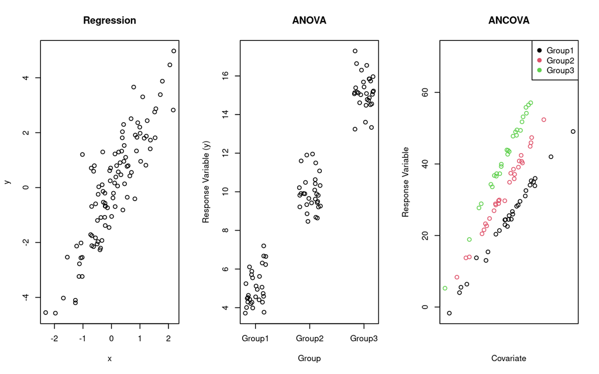

```r
par(mfrow=c(1,3))
# Set seed for reproducibility
set.seed(123)

# Simulate Regression data
x <- rnorm(100)  # 100 random numbers from a normal distribution
y <- 2 * x + rnorm(100)  # y is linearly dependent on x with some noise
plot(x, y, main = "Regression",  xlab = "x", ylab = "y")

# Simulate ANOVA data
n <- 30
x <- factor(rep(c("Group1", "Group2", "Group3"), each = n))
y <- c(rnorm(n, mean = 5, sd = 1),    # Group 1
       rnorm(n, mean = 10, sd = 1),   # Group 2
       rnorm(n, mean = 15, sd = 1))   # Group 3
plot(jitter(as.numeric(x)), y,
     xlab = "Group", ylab = "Response Variable (y)",
     main = "ANOVA",
      xaxt = 'n')
axis(1, at = 1:3, labels = levels(x))

# Ancova
n <- 30
factor_var <- factor(rep(c("Group1", "Group2", "Group3"), each = n))
covariate <- rnorm(n * 3, mean = 10, sd = 5)
response <- c(
  5 + 2 * covariate[1:n] + rnorm(n, sd = 1),    # Group 1
  10 + 2.5 * covariate[(n + 1):(2 * n)] + rnorm(n, sd = 1),   # Group 2
  15 + 3 * covariate[(2 * n + 1):(3 * n)] + rnorm(n, sd = 1)   # Group 3
)

# Create a scatterplot with jitter to visualize the data
plot(covariate, response, col = as.numeric(factor_var),
     xlab = "Covariate", ylab = "Response Variable",
     main = "ANCOVA",
     xaxt = 'n')
legend("topright", legend = levels(factor_var), col = 1:3, pch = 19)
```

- Three cases of linear models:
  - Regression models: Continuous variable ~ continuous variable
  - ANOVA models: Continuous variable ~ qualitative variable
  - ANCOVA models: blend of ANOVA and regression. It assesses the impact of one or more categorical independent variables (factors) on a continuous dependent variable while controlling for the effect of one or more continuous covariates

## ANOVA models

We will divide it into following main sections:

- Motivation: why do we need ANOVA?
- Models: writing a simple model
- Parameter estimation: OLS method
- Partitioning the variability: ANOVA table
- Hyphothesis test: F value

### Motivation

Let’s start with a simple example: plants in the field with different production. What is creating this variation across genotypes?

- Different individuals ?
- Some plants received more water/fertilizer than others?

We can quantify if this observed variation was created by differences at the genetic level, environmental conditions, or errors. In the quantitative genetics, we can write it in the form of **statistical models**, and investigate the importance of the sources of variation.

Below, a very simple illustration and some comments:

- Each square is a genotype (plant in the field) with different mean fruit size
- The goal, is to select plants that produce larger fruits
- If we look only figure 1 (phenotype), what genotype will be selected ? At the right size !
- Now, if we use statistics (and experimental design) we can separete the sources of variation into genotype and environments
- Well, that is a trend in created by the environments. For example, plants at the right size of the field are getting significantly more fertilizer than the rest.
- Should we change our decision? Probably, yes !
- We should focus on selecting individuals that present higher genetic values.

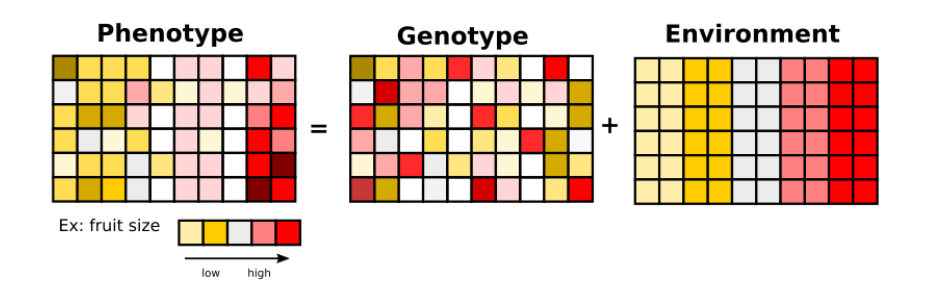

Simple example on the use of ANOVA models to split the variance into source of variations

### Models

- Most of the models presented during the classes will be focused on ANOVA
- We will start with a very simple example: how to compare the phenotypic mean of two genotypes?

In the example below, we will simulate two genotypes (genoA and genoB) and a phenotypic trait (fruit size, for example). We have four repetitions per genotype. If the idea is just to compare the means, we can use the tradicional t-test presented into Stat 101 classes:

```r
# Fruit size evaluate
genoA = c(20.8,30.2,30.2,21.8)
genoB = c(40.1,35.9,40.1,33.6)

t.test(genoA, genoB, var.equal = TRUE)
```

```
##
##  Two Sample t-test
##
## data:  genoA and genoB
## t = -3.8391, df = 6, p-value = 0.008568
## alternative hypothesis: true difference in means is not equal to 0
## 95 percent confidence interval:
##  -19.116238  -4.233762
## sample estimates:
## mean of x mean of y
##    25.750    37.425
```

**How to write it into a model?**

- We can start by modeling the averages, as:
  - $y_1 = \mu_1 + e_1$
  - $y_2 = \mu_2 + e_2$
- We can also model it as deviations from a common mean, as:
  - $y_1 = \mu + \tau_1 + e_1$
  - $y_2 = \mu + \tau_2 + e_2$

The example below is from [Kruschke (2015)](https://jkkweb.sitehost.iu.edu/DoingBayesianDataAnalysis/). The idea behind this model (ANOVA analyses) is to have a baseline level (in this case, we consider the general mean $\beta_0$), and each category of the predictor (ex: genoA and genoB) indicates a deflection above or below this baseline

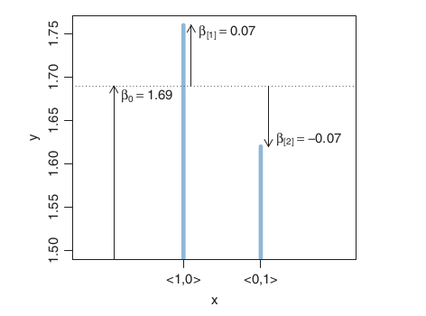

But in the original data set, we have four repetitions and need to write it into specific models:

- $y_{11}= \mu + \tau_1 + e_{11}$
- $y_{12}= \mu + \tau_1 + e_{12}$
- $y_{13}= \mu + \tau_1 + e_{13}$
- $y_{14}= \mu + \tau_1 + e_{14}$
- $y_{21}= \mu + \tau_2 + e_{21}$
- $y_{22}= \mu + \tau_2 + e_{22}$
- $y_{23}= \mu + \tau_2 + e_{23}$
- $y_{24}= \mu + \tau_2 + e_{24}$

Or, we can just simplify it by writing into this form:

$$y_{ij} = \mu + \tau_i +
e_{ij}$$

where: - i = 1,2 and represents the different genotypes - j = 1,2,3,4 and represents the different repetitions

### Parameter estimation

- We have a group of parameters to be estimated, that includes the overall mean, genotypic effects, and the error.
- You can think of parameters as control knobs on statistical devices that simulate data generation. If you change the value of a parameter, it changes a trend in the data, just like if you change the volume control on a music player, it changes the intensity of the sound coming out of the player.
- Some assumptions: errors are independent and identically distributed.
- Estimation (OLS): we want to estimate parameter values that minimizes the sim of squares of deviation of the observed phenotypic values (y) from their predicted values.

$$\hat{\beta} = (X'X)^{-1}
X'y$$

```r
# Parameter estimation
y= c(20.8,30.2,30.2,21.8,40.1,35.9,40.1,33.6)
X <- matrix(c(1,1,1,1,1,1,1,1,
              1,1,1,1,0,0,0,0,
              0,0,0,0,1,1,1,1),
            ncol = 3)
(XlX <- t(X) %*% X)
(Xly <- t(X) %*% y)
beta_hat <- solve(XlX) %*% Xly
```

```
Error in solve.default(XlX) :
  Lapack routine dgesv: system is exactly singular: U[3,3] = 0
```

### Constrains

**Constrains in R**

- The native `lm()` function constrain the model in reference to the first level of the factor, in a way that $\tau_1 =0$
- All the effects will be estimated using the first level as a reference.

Below, the model:

$$\begin{bmatrix}
y_{11} \\
y_{12} \\
y_{13} \\
y_{14} \\
y_{21} \\
y_{22} \\
y_{23} \\
y_{24}
\end{bmatrix} =
\begin{bmatrix}
1 & 0 \\
1 & 0 \\
1 & 0 \\
1 & 0 \\
1 & 1 \\
1 & 1 \\
1 & 1 \\
1 & 1
\end{bmatrix}
\begin{bmatrix}
\mu \\
\tau_2
\end{bmatrix} +
\begin{bmatrix}
\epsilon_{11} \\
\epsilon_{12} \\
\epsilon_{13} \\
\epsilon_{14} \\
\epsilon_{21} \\
\epsilon_{22} \\
\epsilon_{23} \\
\epsilon_{24}
\end{bmatrix}$$

```r
# Parametrization 1
y= c(20.8,30.2,30.2,21.8,40.1,35.9,40.1,33.6)
X <- matrix(c(1,1,1,1,1,1,1,1,
              0,0,0,0,1,1,1,1),
            ncol = 2)
XlX <- t(X) %*% X
Xly <- t(X) %*% y
beta_hat <- solve(XlX) %*% Xly
beta_hat
```

```
##        [,1]
## [1,] 25.750
## [2,] 11.675
```

```r
# Same parametrization in R
genotype <- factor(rep(c("A", "B"), each = 4))
(fm <- lm(y ~ genotype))
```

```
##
## Call:
## lm(formula = y ~ genotype)
##
## Coefficients:
## (Intercept)    genotypeB
##       25.75        11.68
```

**Other options**

```r
# No intercept (mean value)
(fm <- lm(y ~ 0 + genotype))
```

```
##
## Call:
## lm(formula = y ~ 0 + genotype)
##
## Coefficients:
## genotypeA  genotypeB
##     25.75      37.42
```

```r
# Model with the sum-to-zero constraint:
contrasts(genotype) <- contr.sum
(fm <- lm(y ~ genotype))
```

```
##
## Call:
## lm(formula = y ~ genotype)
##
## Coefficients:
## (Intercept)    genotype1
##      31.587       -5.838
```

### Partitioning Variability

- Now that we have an estimate of parameters of the models, the goal is to quantify the proportion of the total variability explained by the model.
- The goal: $H_0: \tau_1 = \tau_2=0$
- Reduced vs. Full Model
  - What is the best model? Different ways to answer it
  - We can look at the residual !

```r
# Reduced model (only the intercept)
reduced_model <- lm(y ~ 1)
anova(reduced_model)
```

```
## Analysis of Variance Table
##
## Response: y
##           Df Sum Sq Mean Sq F value Pr(>F)
## Residuals  7 383.59  54.798
```

```r
# Full model
full_model <- lm(y ~ genotype)
anova(full_model)
```

```
## Analysis of Variance Table
##
## Response: y
##           Df Sum Sq Mean Sq F value   Pr(>F)
## genotype   1 272.61 272.611  14.739 0.008568 **
## Residuals  6 110.98  18.496
## ---
## Signif. codes:  0 '***' 0.001 '**' 0.01 '*' 0.05 '.' 0.1 ' ' 1
```

### Hyphothesis test: F value

- F statistic is calculated by the ratio of the treatment and appropriate error mean squares
- $H_0: \tau_1 = \tau_2=0$
- Because the null hypothesis involves a single parameter (1 degree of freedom), the F and t-tests are equivalent.

```r
# F test from anova
pf(14.739, df1 = 1, df2 = 6, lower.tail = FALSE)
```

```
## [1] 0.008567486
```

```r
# t-test
t.test(genoA, genoB, var.equal = TRUE)
```

```
##
##  Two Sample t-test
##
## data:  genoA and genoB
## t = -3.8391, df = 6, p-value = 0.008568
## alternative hypothesis: true difference in means is not equal to 0
## 95 percent confidence interval:
##  -19.116238  -4.233762
## sample estimates:
## mean of x mean of y
##    25.750    37.425
```

# Conclusion

- Model is a mathematical representation of our understanding of the biological process that explains our observations.
- In quantitative genetics, we will write models where the phenotypic variation is a function of variations at the genotype and environmental levels.
- Matrix notation can be used to write models and therefore describe genetic processes
- REML is a statistical approach used for estimate genetic and non-genetic parameters

# References

- Rencher and Schaaljf. Linear Models in Statistics.[Book link](https://www.amazon.com/Linear-Models-Statistics-Alvin-Rencher/dp/0471754986)
- Isik et al., 2017. Genetic Data Analysis for Plant and Animal Breeding. [Book link](https://www.springer.com/gp/book/9783319551753)

[figure not shown]